## Question - 2

```r
library(tidyverse)
library(caret)
library(pROC)
# Load and clean data
model_df <- read.csv("Model_Building_Data.csv")
model_df <- model_df[!is.na(model_df$TotalCharges), ]

# Convert Status to factor with correct reference level
model_df$Status <- factor(model_df$Status, levels = c("Current", "Left"))

# Train-test split (80/20)
set.seed(123)
train_index <- createDataPartition(model_df$Status, p = 0.8, list = FALSE)
train_df <- model_df[train_index, ]
test_df <- model_df[-train_index, ]

# Logistic regression model (using all variables)
log_model <- glm(Status ~ Gender + SeniorCitizen + Partner + Dependents +
                   Tenure + PhoneService + MultipleLines + InternetService +
                   OnlineSecurity + DeviceProtection + StreamingMovies +
                   Contract + PaperlessBilling + PaymentMethod +
                   MonthlyCharges + TotalCharges,
                 data = train_df, family = "binomial")

# Model summary
summary(log_model)
```

```
##
## Call:
## glm(formula = Status ~ Gender + SeniorCitizen + Partner + Dependents +
##     Tenure + PhoneService + MultipleLines + InternetService +
##     OnlineSecurity + DeviceProtection + StreamingMovies + Contract +
##     PaperlessBilling + PaymentMethod + MonthlyCharges + TotalCharges,
##     family = "binomial", data = train_df)
##
## Coefficients: (4 not defined because of singularities)
##                                        Estimate Std. Error z value Pr(>|z|)
## (Intercept)                           2.803e-01  3.089e-01   0.908 0.364074
## GenderMale                            6.911e-03  7.589e-02   0.091 0.927436
## SeniorCitizen                         3.056e-01  9.779e-02   3.125 0.001779 **
## PartnerYes                            4.134e-03  9.057e-02   0.046 0.963596
## DependentsYes                        -1.849e-01  1.050e-01  -1.762 0.078143 .
## Tenure                               -6.398e-02  7.501e-03  -8.530  < 2e-16 ***
## PhoneServiceYes                      -5.431e-01  2.110e-01  -2.574 0.010060 *
## MultipleLinesNo phone service                NA         NA      NA       NA
## MultipleLinesYes                      2.334e-01  1.013e-01   2.304 0.021234 *
## InternetServiceFiber optic            1.107e+00  2.136e-01   5.184 2.18e-07 ***
## InternetServiceNo                    -8.469e-01  2.714e-01  -3.120 0.001809 **
## OnlineSecurityNo internet service            NA         NA      NA       NA
## OnlineSecurityYes                    -3.775e-01  1.039e-01  -3.634 0.000279 ***
## DeviceProtectionNo internet service          NA         NA      NA       NA
## DeviceProtectionYes                  -4.338e-02  1.028e-01  -0.422 0.672897
## StreamingMoviesNo internet service           NA         NA      NA       NA
## StreamingMoviesYes                    2.853e-01  1.324e-01   2.155 0.031137 *
## ContractOne year                     -7.025e-01  1.256e-01  -5.595 2.21e-08 ***
## ContractTwo year                     -1.633e+00  2.145e-01  -7.610 2.73e-14 ***
## PaperlessBillingYes                   3.021e-01  8.596e-02   3.515 0.000441 ***
## PaymentMethodCredit card (automatic) -1.345e-01  1.332e-01  -1.009 0.312927
## PaymentMethodElectronic check         3.498e-01  1.096e-01   3.192 0.001411 **
## PaymentMethodMailed check            -8.444e-02  1.332e-01  -0.634 0.526108
## MonthlyCharges                       -6.848e-03  7.701e-03  -0.889 0.373836
## TotalCharges                          3.647e-04  8.466e-05   4.308 1.64e-05 ***
## ---
## Signif. codes:  0 '***' 0.001 '**' 0.01 '*' 0.05 '.' 0.1 ' ' 1
##
## (Dispersion parameter for binomial family taken to be 1)
##
##     Null deviance: 6022.2  on 5190  degrees of freedom
## Residual deviance: 4257.1  on 5170  degrees of freedom
## AIC: 4299.1
##
## Number of Fisher Scoring iterations: 6
```

```r
# Predict probabilities on test data
logistic_prob <- predict(log_model, newdata = test_df, type = "response")

# ROC and AUC
roc_obj <- roc(test_df$Status, logistic_prob)
auc(roc_obj)
```

```
## Area under the curve: 0.8355
```

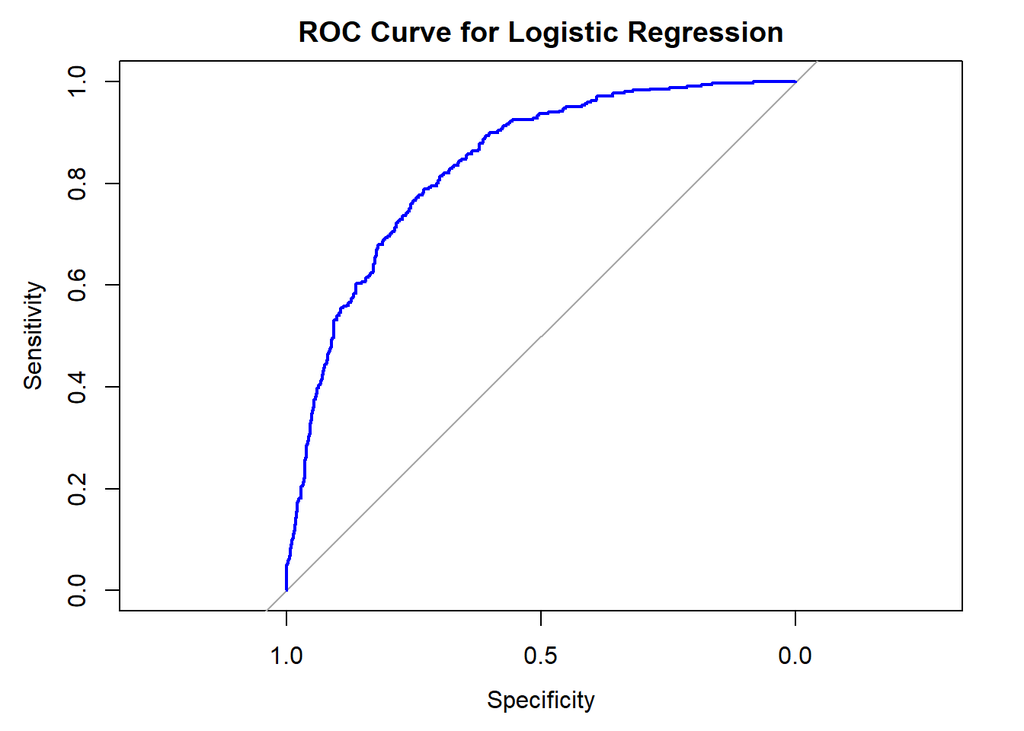

```r
plot(roc_obj, main = "ROC Curve for Logistic Regression", col = "blue")
```

# Logistic Regression Coefficient Interpretations :  
- Tenure (Estimate = -0.06398) - A one-unit increase in tenure (i.e., staying one additional month) reduces the odds of churn by a factor of exp(-0.06398), holding other variables constant.

- TotalCharges (Estimate = 0.0003647)
- A one-unit increase in total charges is associated with a very small increase in the odds of churn by a factor of exp(0.0003647).
- SeniorCitizen (Estimate = 0.3056)
- Being a senior citizen increases the odds of churn by a factor of exp(0.3056) compared to a non-senior, holding all else equal.
- PhoneServiceYes (Estimate = -0.5431)
- Customers with phone service have lower odds of churn by a factor of exp(-0.5431) compared to those without.
- MultipleLinesYes (Estimate = 0.2334)
- Having multiple lines increases the odds of churn by a factor of exp(0.2334) compared to having a single line.
- InternetServiceFiber optic (Estimate = 1.107)
- Customers with fiber optic internet have much higher odds of churn — by a factor of exp(1.107) compared to those with DSL.
- InternetServiceNo (Estimate = -0.8469)
- Customers without internet service have much lower odds of churn — by a factor of exp(-0.8469).
- OnlineSecurityYes (Estimate = -0.3775)
- Customers who have online security are less likely to churn, with odds reduced by a factor of exp(-0.3775.
- StreamingMoviesYes (Estimate = 0.2853)
- Customers who stream movies are more likely to churn, with odds increased by a factor of exp(0.2853).
- ContractOne year (Estimate = -0.7025)
- Customers with a one-year contract have lower odds of churn — by a factor of exp(-0.7025) compared to those with month-to-month plans.
- ContractTwo year (Estimate = -1.633)
- Customers on two-year contracts have much lower odds of churn — by a factor of exp(-1.633).
- PaymentMethodElectronic check (Estimate = 0.3498)
- Customers who pay via electronic check are more likely to churn, with odds increased by a factor of exp(0.3498).